# Community structure

Alain Danet

18 May, 2022

```r
library(vegan)
```

# 1 Diversity

## 1.1 Hill numbers

### 1.1.1 Test on the BCI dataset

```r
data(BCI)
H <- diversity(BCI)
simp <- diversity(BCI, "simpson")
invsimp <- diversity(BCI, "inv")
bci_div <- tibble(
  species_nb = specnumber(BCI),
  shannon = H,
  simp = simp,
  inv_simp = invsimp,
  evenness = H / log(species_nb)
)
```

```r
kable(bci_div) %>%
  kable_styling(bootstrap_options = c("striped", "hover", "condensed")) %>%
  scroll_box(width = "100%", height = "400px")
```

| species_nb | shannon | simp | inv_simp | evenness |
| --- | --- | --- | --- | --- |
| 93 | 4.018412 | 0.9746293 | 39.415554 | 0.8865579 |
| 84 | 3.848471 | 0.9683393 | 31.584877 | 0.8685692 |
| 90 | 3.814059 | 0.9646078 | 28.254778 | 0.8476046 |
| 94 | 3.976563 | 0.9716117 | 35.225771 | 0.8752597 |
| 101 | 3.969940 | 0.9678267 | 31.081657 | 0.8602030 |
| 85 | 3.776575 | 0.9627557 | 26.849731 | 0.8500724 |
| 82 | 3.836811 | 0.9672014 | 30.489077 | 0.8706729 |
| 88 | 3.908381 | 0.9671998 | 30.487609 | 0.8729254 |
| 90 | 3.761331 | 0.9534257 | 21.471056 | 0.8358867 |
| 94 | 3.889803 | 0.9663808 | 29.744868 | 0.8561634 |
| 87 | 3.859814 | 0.9658398 | 29.273803 | 0.8642843 |
| 84 | 3.698414 | 0.9550599 | 22.251827 | 0.8347024 |
| 93 | 3.982373 | 0.9692075 | 32.475442 | 0.8786069 |
| 98 | 4.017494 | 0.9718626 | 35.539830 | 0.8762317 |
| 93 | 3.956635 | 0.9709057 | 34.371015 | 0.8729284 |
| 93 | 3.916821 | 0.9686598 | 31.907937 | 0.8641446 |
| 93 | 3.736897 | 0.9545126 | 21.984098 | 0.8244489 |
| 89 | 3.944985 | 0.9676685 | 30.929617 | 0.8788828 |
| 109 | 4.013094 | 0.9655820 | 29.054548 | 0.8554245 |
| 100 | 4.077327 | 0.9748589 | 39.775449 | 0.8853802 |
| 99 | 3.969925 | 0.9686058 | 31.853043 | 0.8639438 |
| 91 | 3.755413 | 0.9548316 | 22.139382 | 0.8325271 |
| 99 | 4.062575 | 0.9723529 | 36.170213 | 0.8841064 |
| 95 | 3.979427 | 0.9694268 | 32.708387 | 0.8738548 |
| 105 | 4.074718 | 0.9726152 | 36.516635 | 0.8755378 |
| 91 | 3.947749 | 0.9709567 | 34.431303 | 0.8751655 |
| 99 | 3.980281 | 0.9669962 | 30.299529 | 0.8661975 |
| 85 | 3.693896 | 0.9499296 | 19.971863 | 0.8314621 |
| 86 | 3.688721 | 0.9481041 | 19.269343 | 0.8281171 |
| 97 | 3.851598 | 0.9602659 | 25.167317 | 0.8419326 |
| 77 | 3.724967 | 0.9635807 | 27.457940 | 0.8575355 |
| 88 | 3.784873 | 0.9565267 | 23.002620 | 0.8453403 |
| 86 | 3.740392 | 0.9586946 | 24.209883 | 0.8397172 |
| 92 | 3.821670 | 0.9607876 | 25.502106 | 0.8451677 |
| 83 | 2.641859 | 0.7983976 | 4.960258 | 0.5978626 |
| 92 | 3.846109 | 0.9648567 | 28.454909 | 0.8505725 |
| 88 | 3.791703 | 0.9565015 | 22.989309 | 0.8468656 |
| 82 | 3.516082 | 0.9365144 | 15.751596 | 0.7978912 |
| 84 | 3.530494 | 0.9360204 | 15.629977 | 0.7968043 |
| 80 | 3.234849 | 0.9137131 | 11.589250 | 0.7382083 |
| 102 | 4.052495 | 0.9731442 | 37.235945 | 0.8762204 |
| 87 | 3.966614 | 0.9731849 | 37.292428 | 0.8881987 |
| 86 | 3.736254 | 0.9569632 | 23.235938 | 0.8387881 |
| 81 | 3.705016 | 0.9578733 | 23.737903 | 0.8431126 |
| 81 | 3.609518 | 0.9528853 | 21.224806 | 0.8213811 |
| 86 | 3.810489 | 0.9646728 | 28.306797 | 0.8554539 |
| 102 | 3.920917 | 0.9672083 | 30.495526 | 0.8477709 |
| 91 | 3.913725 | 0.9676412 | 30.903463 | 0.8676229 |
| 91 | 3.778851 | 0.9609552 | 25.611603 | 0.8377231 |
| 93 | 3.906616 | 0.9679784 | 31.228916 | 0.8618931 |

### 1.1.2 Test on my dataset

```r
tar_load(c(hillnb, chao_hillnb))

colnames(chao_hillnb) <- str_replace(colnames(chao_hillnb), "chao_", "")
chao_hillnb <- chao_hillnb %>%
  mutate(type = "chao") %>%
  select(op_id, richness:last_col())

chao_hillnb %>%
  filter(is.na(evenness)) %>%
  mutate(evenness2 = shannon / log(richness))
```

```
#> # A tibble: 0 x 7
#> # ... with 7 variables: op_id <chr>, richness <dbl>, shannon <dbl>,
#> #   simpson <dbl>, evenness <dbl>, type <chr>, evenness2 <dbl>
```

```r
hillnb <- hillnb %>%
  rename(richness = species_nb) %>%
  mutate(type = "classic") %>%
  select(op_id, type, richness, shannon, simpson, evenness)

div <- rbind(chao_hillnb, hillnb)
```

```r
div_summary <- div %>%
  group_by(type) %>%
  summarise(
    across(
      where(is.double),
      ~list(
        enframe(
          summary_distribution(x = .x)
        )
      )
    )
    ) %>%
  pivot_longer(cols = c(richness:evenness), names_to = "facet", values_to =
    "biodiversity") %>%
  unnest(cols = "biodiversity") %>%
  pivot_wider(names_from = "name", values_from = "value")
```

```r
div_summary %>%
  kable(.,
    caption = "Summary of diversity indices distribution",
    label = "tab:div-comp"
  ) %>%
  kable_styling(bootstrap_options = c("striped", "hover", "condensed"))
```

| type | facet | min | 1st_quart | median | 2nd_quart | max | mean | sd | n | n_na | frac_na |
| --- | --- | --- | --- | --- | --- | --- | --- | --- | --- | --- | --- |
| chao | richness | 1 | 1.9790000 | 4.1780000 | 8.1880000 | 85.7130000 | 6.1143964 | 5.9586747 | 51725 | 0 | 0 |
| chao | shannon | 0 | 1.5850000 | 2.5750000 | 4.3750000 | 33.6330000 | 3.2613565 | 2.7937840 | 51725 | 0 | 0 |
| chao | simpson | 0 | 1.3460000 | 2.1040000 | 3.3670000 | 40.0000000 | 2.5571477 | 2.0497619 | 51725 | 0 | 0 |
| chao | evenness | 0 | 1.5555482 | 2.0965455 | 2.5034905 | 38.2479784 | 2.0037066 | 1.4156655 | 51725 | 0 | 0 |
| classic | richness | 1 | 2.0000000 | 5.0000000 | 9.0000000 | 72.0000000 | 6.7342291 | 6.4739226 | 51725 | 0 | 0 |
| classic | shannon | 0 | 0.4928513 | 0.9643630 | 1.4783056 | 3.5447334 | 0.9908712 | 0.6709456 | 51725 | 0 | 0 |
| classic | simpson | 0 | 0.2677684 | 0.5267097 | 0.7042254 | 0.9569657 | 0.4761225 | 0.2755499 | 51725 | 0 | 0 |
| classic | evenness | 0 | 0.4211752 | 0.6481166 | 0.7718266 | 1.0000000 | 0.5678811 | 0.2846442 | 51725 | 0 | 0 |

- Chao indices leads to higher values of evenness, shannon and simpson, in average and also to more spread values

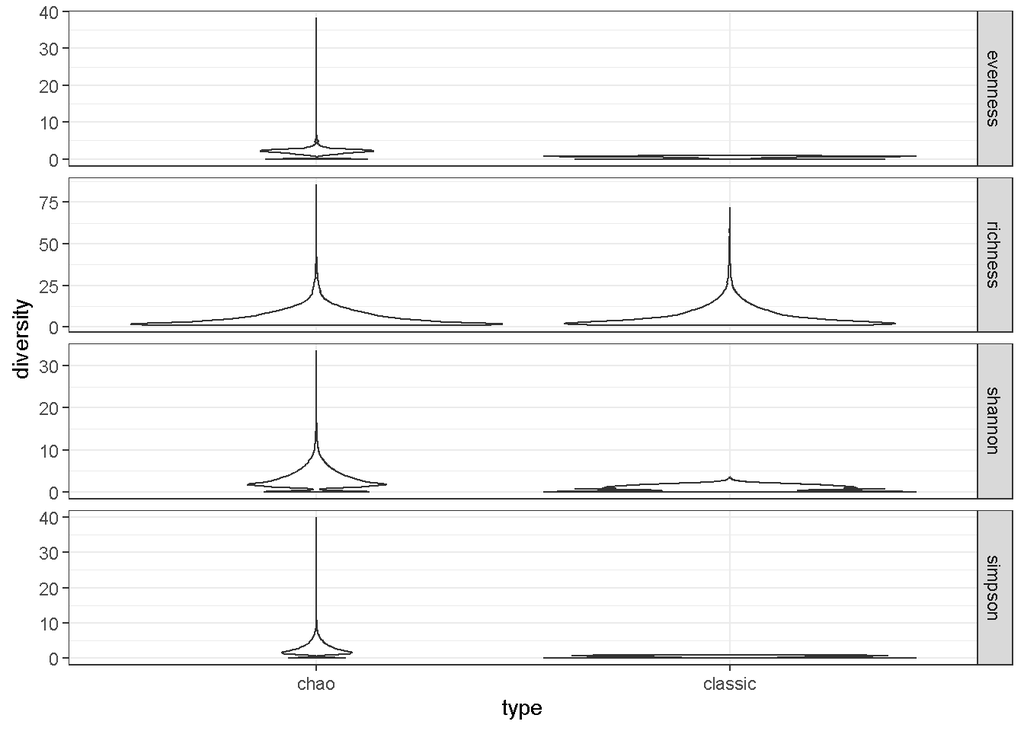

```r
div %>%
  pivot_longer(cols = c(richness:evenness), names_to = "facet", values_to =
    "diversity") %>%
ggplot(aes(y = diversity, x = type)) +
geom_violin() +
facet_grid(rows = vars(facet), scales = "free_y")
```

- Look at infinit values (now fixed, it was for richness == 1)
- Computed on chao estimations of shannon and richness, most values pielou evenness are above one:

```r
chao_hillnb %>%
  filter(evenness > 1) %>%
  slice(1:30) %>%
  kable %>%
  kable_styling(bootstrap_options = c("striped", "hover", "condensed")) %>%
  scroll_box(width = "100%", height = "400px")
```

| op_id | richness | shannon | simpson | evenness | type |
| --- | --- | --- | --- | --- | --- |
| bal288 | 4.619 | 3.303 | 2.620 | 2.158572 | chao |
| bal289 | 3.816 | 1.903 | 1.397 | 1.420995 | chao |
| bal290 | 7.882 | 3.074 | 2.255 | 1.488922 | chao |
| bal291 | 2.843 | 2.219 | 1.933 | 2.123730 | chao |
| bal292 | 2.946 | 2.552 | 2.296 | 2.361982 | chao |
| bal293 | 4.722 | 2.167 | 1.721 | 1.396054 | chao |
| bal294 | 3.142 | 1.657 | 1.344 | 1.447339 | chao |
| bal295 | 4.917 | 4.314 | 3.884 | 2.708610 | chao |
| bal298 | 7.707 | 3.312 | 2.266 | 1.621837 | chao |
| bal299 | 4.814 | 3.613 | 3.165 | 2.299036 | chao |
| bal300 | 5.576 | 3.129 | 2.555 | 1.820804 | chao |
| bal301 | 2.909 | 2.329 | 2.030 | 2.181101 | chao |
| bal303 | 3.849 | 1.791 | 1.383 | 1.328819 | chao |
| bal304 | 6.985 | 4.086 | 3.180 | 2.102106 | chao |
| bal305 | 6.880 | 4.486 | 3.165 | 2.326017 | chao |
| bal306 | 3.245 | 2.480 | 2.096 | 2.106845 | chao |
| bal307 | 4.382 | 1.814 | 1.379 | 1.227745 | chao |
| bal312 | 11.725 | 8.136 | 6.409 | 3.305002 | chao |
| bal313 | 1.667 | 1.587 | 1.500 | 3.105520 | chao |
| bal317 | 6.544 | 3.811 | 3.149 | 2.028694 | chao |
| bal318 | 6.048 | 3.378 | 2.738 | 1.876951 | chao |
| bal319 | 7.985 | 4.854 | 3.444 | 2.336389 | chao |
| bal320 | 12.726 | 7.499 | 5.746 | 2.948129 | chao |
| bal322 | 3.917 | 2.877 | 2.351 | 2.107189 | chao |
| bal323 | 3.080 | 2.281 | 1.963 | 2.027682 | chao |
| bal324 | 2.852 | 2.402 | 2.208 | 2.291940 | chao |
| bal325 | 8.682 | 4.895 | 3.309 | 2.264891 | chao |
| bal326 | 10.921 | 7.018 | 5.376 | 2.935557 | chao |
| bal328 | 9.338 | 2.973 | 1.853 | 1.330742 | chao |
| bal329 | 8.850 | 4.904 | 3.256 | 2.249111 | chao |

### 1.1.3 Relationships between Chao and classic number

```r
div <- div %>%
  arrange(op_id, type)
stopifnot(all(div[div$type == "chao", ]$op_id == div[div$type == "classic", ]$op_id))
```

```r
old_par <- par()
png(here("doc", "fig", "index_chao_classic_comparison.png"))
par(mfrow = c(2, 2))
for (i in c("richness", "shannon", "simpson", "evenness")) {
  plot(
    div[div$type == "chao", ][[i]] ~ div[div$type == "classic", ][[i]],
    ylab = "Chao",
    xlab = "Classic"
  )
  abline(1, 1)
  title(i)
}
dev.off()
```

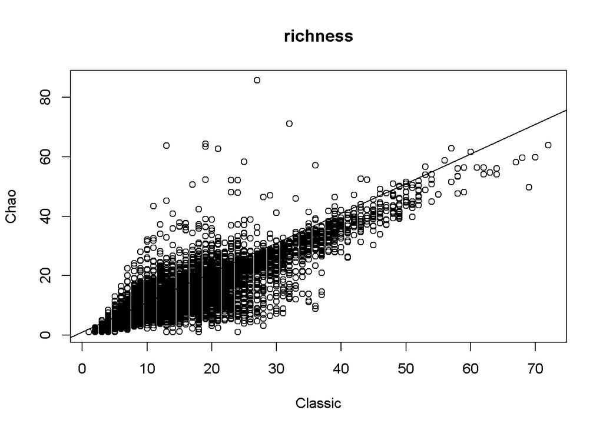

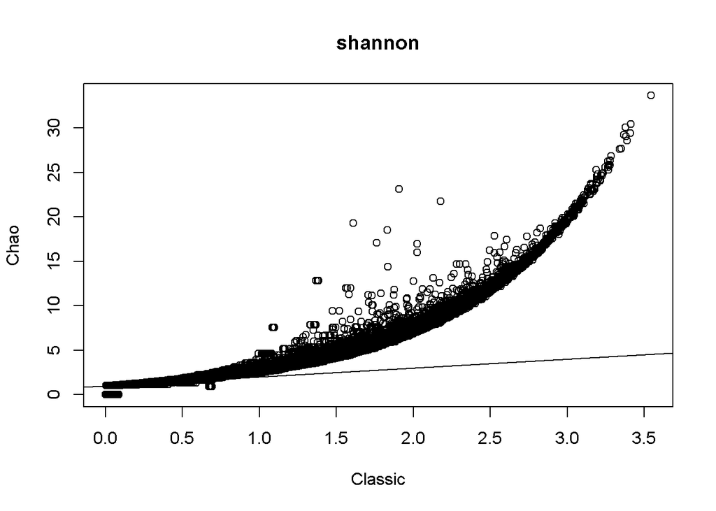

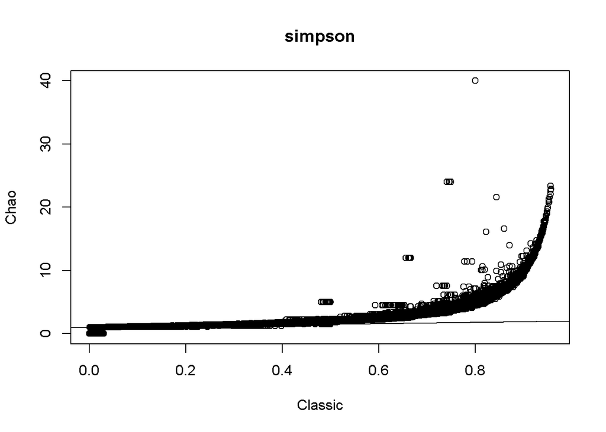

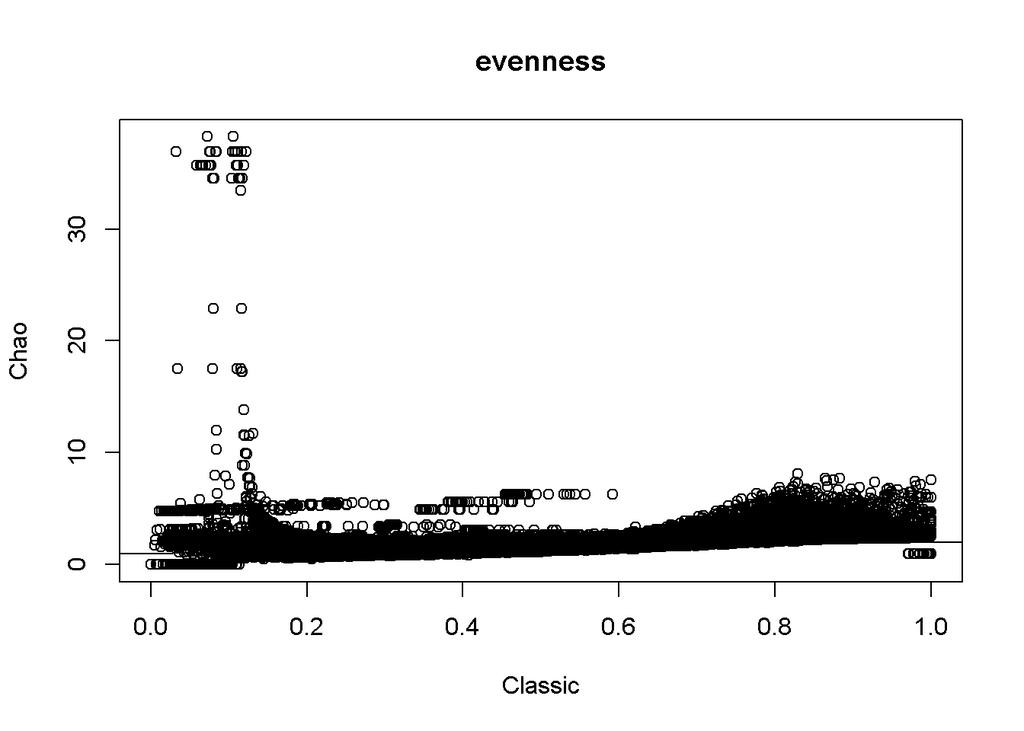

```r
for (i in c("richness", "shannon", "simpson", "evenness")) {
  plot(
    div[div$type == "chao", ][[i]] ~ div[div$type == "classic", ][[i]],
    ylab = "Chao",
    xlab = "Classic"
  )
  abline(1, 1)
  title(i)
}
```

```r
par(old_par)
```

## 1.2 Chao

### 1.2.1 Test

```r
test <- filtered_dataset$measurement %>%
  filter(op_id %in% unique(op_id)[1:2])
ti <- get_chao_hillnb(
  x = test,
  coverage = .985,
  confidence_int = NULL)
```

# 2 Turnover

## 2.1 Data

```r
tar_load(c(
    rigal_trends,
    var_temporal_trends,
    turnover_types_chr,
    vegdist_index
  )
)
names(rigal_trends) <- var_temporal_trends
trend_vegdist <- rigal_trends[
  names(rigal_trends) %in% c(turnover_types_chr, vegdist_index, "hillebrand")
  ]
trend_vegdist_slope <- map_dfr(trend_vegdist,
  ~.x[, c("siteid", "linear_slope")], .id = "response")
```

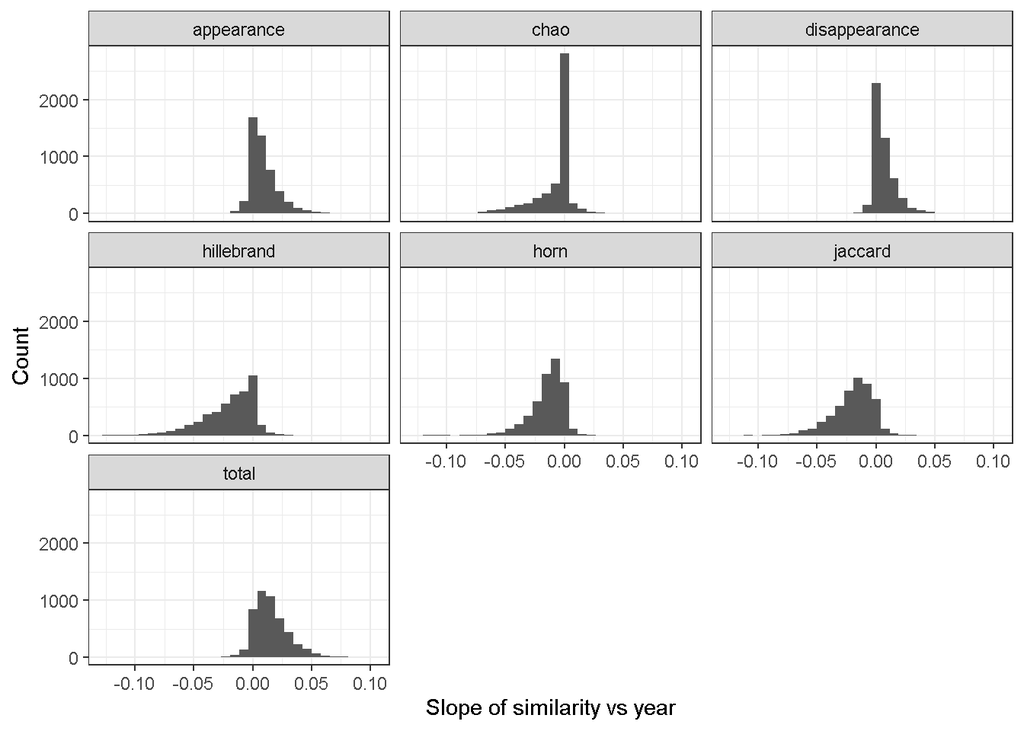

```r
p_trend_vegdist_slope <- trend_vegdist_slope %>%
  ggplot(aes(x = linear_slope)) +
  geom_histogram() +
  facet_wrap(~response) +
  labs(y = "Count", x = "Slope of similarity vs year")
p_trend_vegdist_slope
```

```r
save_plot(
  here("doc", "fig", "slope_hist_vegdist.png"),
  p_trend_vegdist_slope
)
trend_vegdist_slope_summary <-
  trend_vegdist_slope %>%
  group_by(response) %>%
  summarise(
    summary_dist = list(
      enframe(summary_distribution(linear_slope))
    )
    ) %>%
  unnest(cols = summary_dist) %>%
  pivot_wider(names_from = "name", values_from = "value")

trend_vegdist_slope_summary %>%
  kable %>%
  kable_styling(bootstrap_options = c("striped", "hover", "condensed"))
```

| response | min | 1st_quart | median | 2nd_quart | max | mean | sd | n | n_na | frac_na |
| --- | --- | --- | --- | --- | --- | --- | --- | --- | --- | --- |
| appearance | -0.0384615 | 0.0000000 | 0.0062610 | 0.0145341 | 0.0986395 | 0.0092583 | 0.0125573 | 4887 | 0 | 0 |
| chao | -0.1209148 | -0.0120252 | 0.0000000 | 0.0000000 | 0.0748988 | -0.0081463 | 0.0174122 | 4887 | 0 | 0 |
| disappearance | -0.0300000 | 0.0000000 | 0.0037460 | 0.0105780 | 0.0827706 | 0.0066368 | 0.0098038 | 4887 | 0 | 0 |
| hillebrand | -0.1258587 | -0.0325640 | -0.0155034 | -0.0030948 | 0.0634554 | -0.0204526 | 0.0223912 | 4887 | 0 | 0 |
| horn | -0.1179941 | -0.0210718 | -0.0116719 | -0.0047326 | 0.0421363 | -0.0145048 | 0.0146991 | 4887 | 0 | 0 |
| jaccard | -0.1209148 | -0.0291357 | -0.0172178 | -0.0077337 | 0.0384615 | -0.0198501 | 0.0174539 | 4887 | 0 | 0 |
| total | -0.0384615 | 0.0054883 | 0.0134750 | 0.0235120 | 0.0986395 | 0.0158951 | 0.0149053 | 4887 | 0 | 0 |

## 2.2 Null model (Unified Neutral theory of biodiversity)

- See `untb::untb()` and neutral_model.R

```r
library(untb)
data(butterflies)
test <- untb(start = butterflies, prob=0, gens=100)

rich_quant <- summary_distribution(filtered_dataset$abun_rich$species_nb)
count_site <- filtered_dataset$site_quali %>%
  filter(unitabundance == "Count") %>%
  .[["siteid"]]

tot_abun_quant <- summary_distribution(
  filtered_dataset$abun_rich %>%
    filter(siteid %in% count_site) %>%
    .$total_abundance
)

null_mod <- get_untb_abun_mat(
  start = sample(1:3, size = 64, replace = TRUE),
  D = 0.1 * 64,
  prob = 0.01,
  gens = 1300
)
sparse <- Matrix::Matrix(null_mod$abun_mat, sparse=TRUE)
object.size(sparse) * 10^-6
```

```
#> 0.1 bytes
```

```r
object.size(null_mod$abun_mat) * 10^-6
```

```
#> 0.1 bytes
```

```r
jaccard_test <-  1 - as.matrix(
  vegdist(
    null_mod$abun_mat[301:nrow(null_mod$abun_mat), ],
    method = "jaccard"
  )
)

lm(as.matrix(jaccard_test)[1,] ~ as.integer(names(as.matrix(jaccard_test)[1,])))
```

```
#>
#> Call:
#> lm(formula = as.matrix(jaccard_test)[1, ] ~ as.integer(names(as.matrix(jaccard_test)[1,
#>     ])))
#>
#> Coefficients:
#>                                     (Intercept)
#>                                       1.1451965
#> as.integer(names(as.matrix(jaccard_test)[1, ]))
#>                                      -0.0003887
```

```r
tar_load(c(neutral_turnover))
```

```r
neutral_turnover <- neutral_turnover %>%
  rowwise(rowid) %>%
  mutate(
    model = list(lm(jaccard ~ year, jaccard)),
    coef = list(broom::tidy(model))
  ) %>%
  ungroup()
```

```r
neutral_turnover_trends <- neutral_turnover %>%
  select(-jaccard, -model) %>%
  unnest(coef) %>%
  filter(term == "year")
```

- Neutral community dynamics generally produce turnover through time: (jaccard mean slope: -0.0019)
- Immigration increases turnover through time (jaccard decrease):
  - when death rate is low
- Higher death rate increases also turnover except when immigration is high

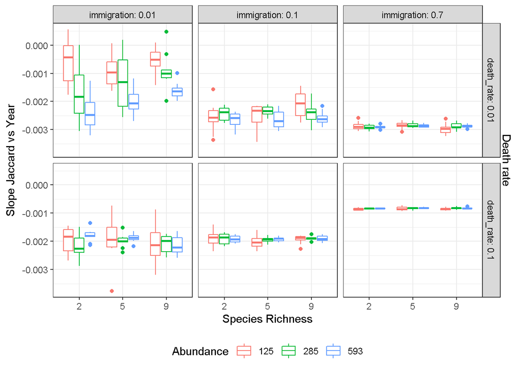

```r
p <- neutral_turnover_trends %>%
  ggplot(aes(y = estimate, x = as.factor(richness), color = as.factor(abun))) +
  geom_boxplot() +
  facet_grid(
    rows = vars(death_rate), cols = vars(immigration),
    labeller = labeller(.cols = label_both, .rows = label_both)
    ) +
  labs(x = "Species Richness", y = "Slope Jaccard vs Year", color = "Abundance")+
  scale_y_continuous(sec.axis = sec_axis(~ . , name = "Death rate", breaks = NULL, labels = NULL)) +
  theme(legend.position = "bottom")
p
```

- Empirical data are far more variable than neutral dynamics, but:
  - also negative in average
  - average close to neutral when immigration is strong and low death rate
  - neutral trends computed over 250 years, data over 10s years
  - Data displays quite a lot of positive turnover

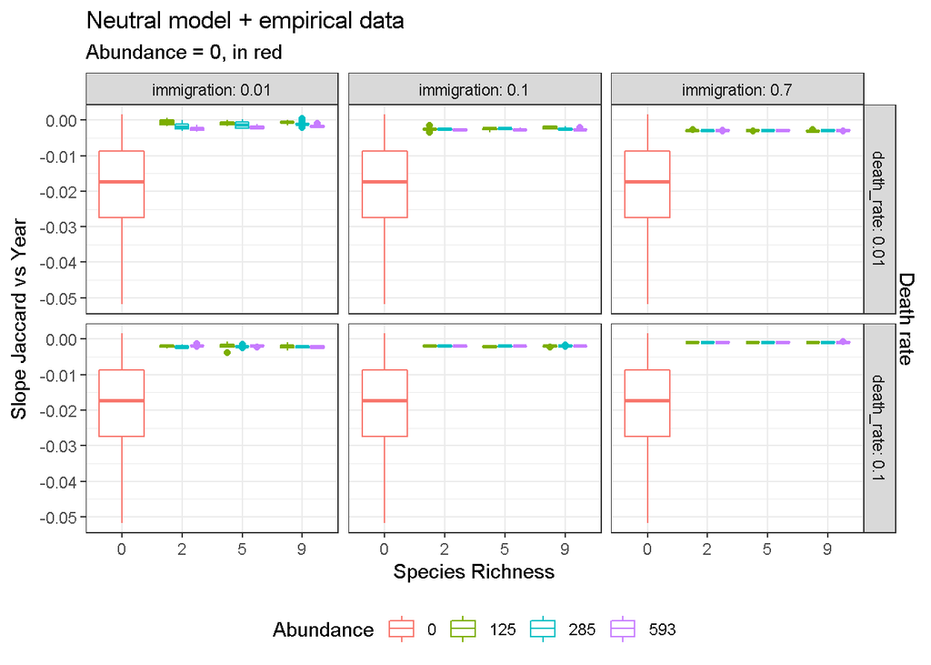

```r
p + geom_boxplot(
  data = trend_vegdist_slope %>%
    filter(response == "jaccard") %>%
    mutate(abun = as.factor(0)) %>%
    filter(
      linear_slope >= quantile(linear_slope, 0.05) &
      linear_slope <= quantile(linear_slope, 0.95)
    ),
  aes(y = linear_slope, x = abun)) +
labs(title = "Neutral model + empirical data", subtitle = "Abundance = 0, in red")
```

## 2.3 Partition in nestedness and turnover

### 2.3.1 TEST

```r
library(betapart)
tar_load(com_mat_site)
ti <- com_mat_site$mat[[1]]
```

```r
core <- betapart.core(decostand(ti, method = "pa"))

data(bbsData)
bbs.t <- beta.temp(bbs1980, bbs2000, index.family="jac")
bbs.t
```

```
#>      beta.jtu    beta.jne   beta.jac
#> AL 0.10126582 0.038128117 0.13939394
#> AK 0.01257862 0.198476660 0.21105528
#> AZ 0.02020202 0.143591083 0.16379310
#> AR 0.07751938 0.078508989 0.15602837
#> CA 0.10238908 0.015060586 0.11744966
#> CO 0.03960396 0.155416786 0.19502075
#> CT 0.05797101 0.039251208 0.09722222
#> DE 0.13333333 0.054166667 0.18750000
#> FL 0.08974359 0.028268833 0.11801242
#> GA 0.14473684 0.005589955 0.15032680
#> ID 0.08866995 0.120731759 0.20940171
#> IL 0.10596026 0.070869003 0.17682927
#> IN 0.09589041 0.018203549 0.11409396
#> IA 0.21276596 0.000000000 0.21276596
#> KS 0.13714286 0.028602999 0.16574586
#> KY 0.06060606 0.040843215 0.10144928
#> LA 0.10000000 0.122222222 0.22222222
#> ME 0.02484472 0.088149630 0.11299435
#> MD 0.08988764 0.010112360 0.10000000
#> MA 0.12738854 0.026932453 0.15432099
#> MI 0.08040201 0.043999904 0.12440191
#> MN 0.08256881 0.028542304 0.11111111
#> MS 0.08849558 0.106816925 0.19531250
#> MO 0.08695652 0.055900621 0.14285714
#> MT 0.09734513 0.059679661 0.15702479
#> NE 0.05128205 0.173848839 0.22513089
#> NV 0.04597701 0.523971175 0.56994819
#> NH 0.07643312 0.060471641 0.13690476
#> NJ 0.11250000 0.052205882 0.16470588
#> NM 0.02234637 0.254513135 0.27685950
#> NY 0.13725490 0.004208513 0.14146341
#> NC 0.11834320 0.062975486 0.18131868
#> ND 0.12290503 0.067816622 0.19072165
#> OH 0.18633540 0.014884108 0.20121951
#> OK 0.08433735 0.102828426 0.18716578
#> OR 0.04405286 0.077404626 0.12145749
#> PA 0.09467456 0.015790560 0.11046512
#> RI 0.45901639 0.178346244 0.63736264
#> SC 0.00000000 0.224637681 0.22463768
#> SD 0.04678363 0.142271101 0.18905473
#> TN 0.08633094 0.088993740 0.17532468
#> TX 0.09774436 0.054199102 0.15194346
#> UT 0.01351351 0.313675427 0.32718894
#> VT 0.15483871 0.031496694 0.18633540
#> VA 0.08750000 0.082954545 0.17045455
#> WA 0.03652968 0.065597979 0.10212766
#> WV 0.08219178 0.047678349 0.12987013
#> WI 0.06930693 0.056274465 0.12558140
#> WY 0.12227074 0.060656087 0.18292683
```

```r
x <- matrix(
  c(1, 0, 1, 1, 0, 1, 1, 0),
  ncol = 2,
  byrow = TRUE,
  dimnames = list(NULL, c("pika", "sala"))
)
x <- as.matrix(decostand(x, method = "pa"))

x[x == 1] <- rpois(n = sum(x == 1), lambda = 5)
x[x > 0] <- 1

compute_jaccard_decomp(x = x[1, ], y = x[2, ])
```

```
#>    jaccard jaccard_ne jaccard_tu
#>        0.5        0.5        0.0
```

```r
compute_jaccard_decomp(x = x[1, ], y = x[3, ])
```

```
#>    jaccard jaccard_ne jaccard_tu
#>          1          0          1
```

```r
compute_jaccard_decomp(x = x[1, ], y = x[1, ])
```

```
#>    jaccard jaccard_ne jaccard_tu
#>          0          0          0
```

### 2.3.2 DATA

```r
tar_load(c(baselga_c, analysis_dataset))
baselga_c
```

```
#> # A tibble: 51,725 x 5
#>    siteid  year jaccard nestedness turnover
#>    <chr>  <dbl>   <dbl>      <dbl>    <dbl>
#>  1 S1      1987   0         0         0
#>  2 S1      1988   0.6       0.6       0
#>  3 S1      1989   0.733     0.733     0
#>  4 S1      1990   0.769     0.369     0.4
#>  5 S1      1992   0.6       0.6       0
#>  6 S1      1993   0.8       0.133     0.667
#>  7 S1      1994   0.429     0.429     0
#>  8 S1      1996   0.769     0.369     0.4
#>  9 S1      1997   0.818     0.152     0.667
#> 10 S1      1998   0.909     0.0519    0.857
#> # ... with 51,715 more rows
```

```r
baselga_summary <-
  baselga_c %>%
  select(-year) %>%
  pivot_longer(cols = -siteid, names_to = "response", values_to = "beta") %>%
  group_by(response) %>%
  summarise(
    summary_dist = list(
      enframe(summary_distribution(beta))
    )
    ) %>%
  unnest(cols = summary_dist) %>%
  pivot_wider(names_from = "name", values_from = "value")

baselga_summary %>%
  kable %>%
  kable_styling(bootstrap_options = c("striped", "hover", "condensed"))
```

| response | min | 1st_quart | median | 2nd_quart | max | mean | sd | n | n_na | frac_na |
| --- | --- | --- | --- | --- | --- | --- | --- | --- | --- | --- |
| jaccard | 0 | 0 | 0.3571429 | 0.5000000 | 1.0000000 | 0.3496014 | 0.2631649 | 51725 | 0 | 0 |
| nestedness | 0 | 0 | 0.0952381 | 0.3000000 | 0.9615385 | 0.1750378 | 0.2098844 | 51725 | 0 | 0 |
| turnover | 0 | 0 | 0.0000000 | 0.3333333 | 1.0000000 | 0.1745636 | 0.2446562 | 51725 | 0 | 0 |

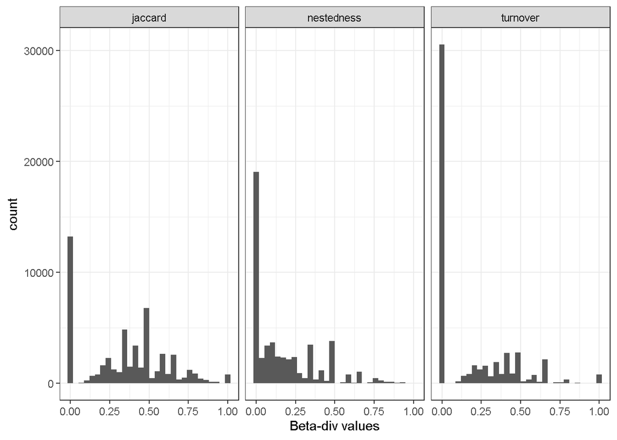

```r
baselga_c %>%
  select(-year) %>%
  pivot_longer(cols = -siteid, names_to = "response", values_to = "beta") %>%
  ggplot(aes(x = beta)) +
  geom_histogram() +
  facet_grid(cols = vars(response)) +
  labs(x = "Beta-div values", main = "Baselga decomposition of dissimilarity in nestedness and turnover")
```

## 2.4 Partition in abundance change and relative abundance change

### 2.4.1 TEST

```r
DD <- function(
  x,
  ref.t = 1,
  zero.rm = FALSE
  ) {

  lmb <- apply(x, 1, sum)
  D2 <- log(lmb / lmb[ref.t])

  x.p <- t(apply(x, 1, function(z) z / sum(z)))
  Pt <- x.p[ref.t,]

  if(zero.rm == FALSE) {
    D1 <- -t(apply(x.p, 1, function(z) ifelse(Pt==0, 0, log(Pt/z)))) %*% Pt
  }else{
    D1 <- -t(apply(x.p, 1, function(z)ifelse(Pt==0|z==0, 0, log(Pt/z)))) %*% Pt
  }

  D <- D1 + D2
  data.frame(D, D1, D2)
}
```

```r
DD(ti, zero.rm = TRUE)
```

```
#>                D         D1        D2
#> 1987  0.00000000  0.0000000 0.0000000
#> 1988  0.01073337 -0.6972289 0.7079623
#> 1989  0.75446089 -0.9129643 1.6674252
#> 1990  0.38373851 -0.4741639 0.8579024
#> 1992 -1.04243587 -2.5547709 1.5123351
#> 1993  1.86647394 -0.6811038 2.5475778
#> 1994 -0.59657405 -1.8472025 1.2506285
#> 1996 -1.66733316 -4.4067278 2.7393946
#> 1997  1.10550200 -0.9084055 2.0139075
#> 1998  2.39873783 -0.2403195 2.6390573
```

# 3 Metacommunity by basin

- Basin with more than 10 sites and followed more than 10 years

```r
tar_load(com_mat_basin)
loc <- filtered_dataset$location %>%
  st_as_sf(coords = c("longitude", "latitude"),
  crs = 4326)
```

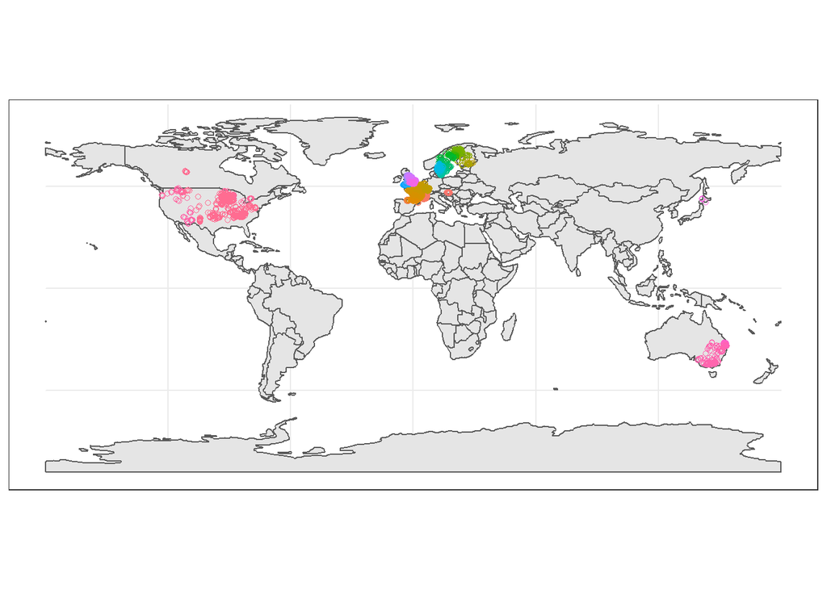

```r
loc_com_basin <- loc %>%
  filter(main_bas %in% unique(com_mat_basin$main_bas))

ggplot(data = ne_countries(returnclass = "sf")) +
    geom_sf() +
    geom_sf(data = loc_com_basin,
      aes(color = as.factor(main_bas)), shape = 1) +
    theme(legend.position = "none")
```

- Basin with 10 same sites followed more than 10 years:

```r
tar_load(filtered_com_mat_basin)

filtered_com_mat_basin$mean_dissimilarity <-
  map_dbl(filtered_com_mat_basin$mat, ~mean(vegdist(.x, method = "bray")))
```

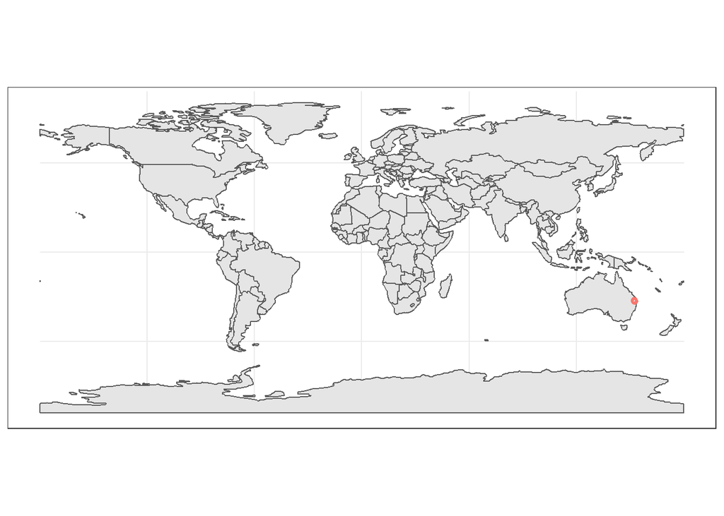

```r
loc_com_basin <- loc %>%
  filter(main_bas %in% unique(filtered_com_mat_basin$main_bas))

ggplot(data = ne_countries(returnclass = "sf")) +
    geom_sf() +
    geom_sf(data = loc %>%
      filter(main_bas %in% unique(filtered_com_mat_basin$main_bas)),
      aes(color = as.factor(main_bas)), shape = 1) +
    theme(legend.position = "none")
```

```r
filtered_com_mat_basin %>%
  ggplot(aes(x = year, mean_dissimilarity)) +
  geom_point() +
  geom_smooth() +
  facet_wrap(~main_bas)
```

[output not shown]

## 3.1 Analysis

## 3.2 Reproducibility

**Reproducibility receipt**

```r
## datetime
Sys.time()
```

```
#> [1] "2022-05-18 09:59:09 CDT"
```

```r
## repository
if(requireNamespace('git2r', quietly = TRUE)) {
  git2r::repository()
} else {
  c(
    system2("git", args = c("log", "--name-status", "-1"), stdout = TRUE),
    system2("git", args = c("remote", "-v"), stdout = TRUE)
  )
}
```

```
#> Local:    main L:/alain/RivFishTimeBiodiversityFacets
#> Remote:   main @ origin (https://github.com/alaindanet/RivFishTimeBiodiversityFacets.git)
#> Head:     [3536845] 2022-05-17: fix data selection
```